# **Clasificación de vinos basada en sus características distintivas mediante SVM, Naive Bayes y análisis discriminante**

### **CREW**

> - Rodolfo Armando Jaramillo Ruiz
> - Luis Ernesto Ortiz Villalón
> - Mario Estrada Ferreira
> - Luis Andrés Burruel Durán

```python
!pip install ucimlrepo
```

```python
#Importación de librerias necesarias para el entrenamiento

import numpy as np
import pandas as pd
import random
import math
from sklearn.model_selection import StratifiedKFold
from sklearn.discriminant_analysis import LinearDiscriminantAnalysis
from sklearn.neighbors import KNeighborsClassifier
from sklearn.naive_bayes import GaussianNB
from sklearn.svm import SVC
from sklearn.tree import DecisionTreeClassifier
from sklearn.metrics import accuracy_score
import matplotlib.pyplot as plt
import seaborn as sns
```

```python
from ucimlrepo import fetch_ucirepo

# fetch dataset
wine_quality = fetch_ucirepo(id=186)

# data (as pandas dataframes)
x = wine_quality.data.features
y = wine_quality.data.targets

print(wine_quality)

# metadata
print(wine_quality.metadata)

# variable information
print(wine_quality.variables)
```

[output not shown]

[output cut: 134 more lines]

# Procesado de datos

```python
wine = pd.concat([x,y], axis = 1)
wine
```

|  | fixed_acidity | volatile_acidity | citric_acid | residual_sugar | chlorides | free_sulfur_dioxide | total_sulfur_dioxide | density | pH | sulphates | alcohol | quality |
| --- | --- | --- | --- | --- | --- | --- | --- | --- | --- | --- | --- | --- |
| 0 | 7.0 | 0.27 | 0.36 | 20.7 | 0.045 | 45.0 | 170.0 | 1.00100 | 3.00 | 0.45 | 8.8 | 6 |
| 1 | 6.3 | 0.30 | 0.34 | 1.6 | 0.049 | 14.0 | 132.0 | 0.99400 | 3.30 | 0.49 | 9.5 | 6 |
| 2 | 8.1 | 0.28 | 0.40 | 6.9 | 0.050 | 30.0 | 97.0 | 0.99510 | 3.26 | 0.44 | 10.1 | 6 |
| 3 | 7.2 | 0.23 | 0.32 | 8.5 | 0.058 | 47.0 | 186.0 | 0.99560 | 3.19 | 0.40 | 9.9 | 6 |
| 4 | 7.2 | 0.23 | 0.32 | 8.5 | 0.058 | 47.0 | 186.0 | 0.99560 | 3.19 | 0.40 | 9.9 | 6 |
| ... | ... | ... | ... | ... | ... | ... | ... | ... | ... | ... | ... | ... |
| 4893 | 6.2 | 0.21 | 0.29 | 1.6 | 0.039 | 24.0 | 92.0 | 0.99114 | 3.27 | 0.50 | 11.2 | 6 |
| 4894 | 6.6 | 0.32 | 0.36 | 8.0 | 0.047 | 57.0 | 168.0 | 0.99490 | 3.15 | 0.46 | 9.6 | 5 |
| 4895 | 6.5 | 0.24 | 0.19 | 1.2 | 0.041 | 30.0 | 111.0 | 0.99254 | 2.99 | 0.46 | 9.4 | 6 |
| 4896 | 5.5 | 0.29 | 0.30 | 1.1 | 0.022 | 20.0 | 110.0 | 0.98869 | 3.34 | 0.38 | 12.8 | 7 |
| 4897 | 6.0 | 0.21 | 0.38 | 0.8 | 0.020 | 22.0 | 98.0 | 0.98941 | 3.26 | 0.32 | 11.8 | 6 |

4898 rows × 12 columns

```python
description = wine.describe()

description.drop('count')
```

|  | fixed_acidity | volatile_acidity | citric_acid | residual_sugar | chlorides | free_sulfur_dioxide | total_sulfur_dioxide | density | pH | sulphates | alcohol | quality |
| --- | --- | --- | --- | --- | --- | --- | --- | --- | --- | --- | --- | --- |
| mean | 6.854788 | 0.278241 | 0.334192 | 6.391415 | 0.045772 | 35.308085 | 138.360657 | 0.994027 | 3.188267 | 0.489847 | 10.514267 | 5.877909 |
| std | 0.843868 | 0.100795 | 0.121020 | 5.072058 | 0.021848 | 17.007137 | 42.498065 | 0.002991 | 0.151001 | 0.114126 | 1.230621 | 0.885639 |
| min | 3.800000 | 0.080000 | 0.000000 | 0.600000 | 0.009000 | 2.000000 | 9.000000 | 0.987110 | 2.720000 | 0.220000 | 8.000000 | 3.000000 |
| 25% | 6.300000 | 0.210000 | 0.270000 | 1.700000 | 0.036000 | 23.000000 | 108.000000 | 0.991723 | 3.090000 | 0.410000 | 9.500000 | 5.000000 |
| 50% | 6.800000 | 0.260000 | 0.320000 | 5.200000 | 0.043000 | 34.000000 | 134.000000 | 0.993740 | 3.180000 | 0.470000 | 10.400000 | 6.000000 |
| 75% | 7.300000 | 0.320000 | 0.390000 | 9.900000 | 0.050000 | 46.000000 | 167.000000 | 0.996100 | 3.280000 | 0.550000 | 11.400000 | 6.000000 |
| max | 14.200000 | 1.100000 | 1.660000 | 65.800000 | 0.346000 | 289.000000 | 440.000000 | 1.038980 | 3.820000 | 1.080000 | 14.200000 | 9.000000 |

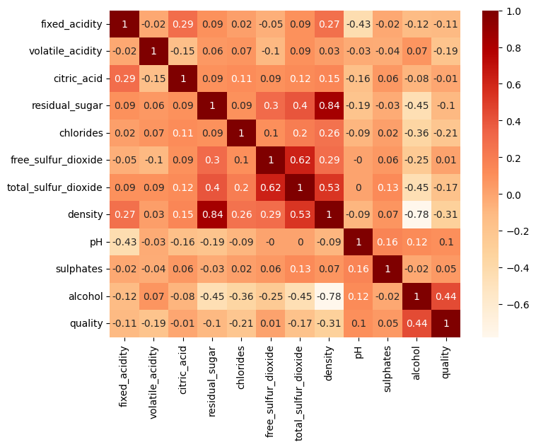

```python
# Matriz de correlación entre las variables
correlation = wine.corr().round(2)
plt.figure(figsize=(8, 6))
sns.heatmap(correlation, annot=True, cmap = 'OrRd')
```

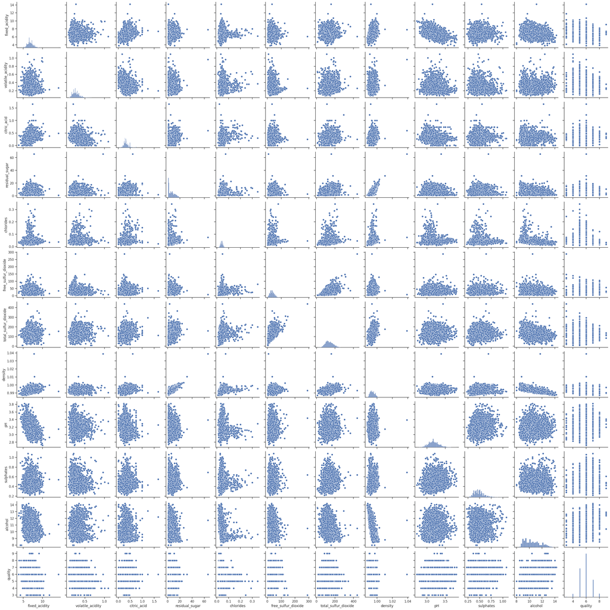

```python
# Un diagrama de pares muestra con diagramas de disersión la relación entre variables.
sns.set(style="ticks")
sns.pairplot(wine)
plt.show()
```

[figure not shown]

```python
# Variables de más alta correlación

fig, axs = plt.subplots(2, 2, figsize=(20, 10))

axs[0, 0].hist(wine['quality'], bins = 6, color='yellow', edgecolor = 'black')
axs[0, 0].set_title('Distribución de las calificaciones a los vinos')
axs[0, 0].set_xlabel('Calificación')

axs[0, 1].scatter(wine['residual_sugar'], wine['density'], marker = 'x', color = 'pink')
axs[0, 1].set_title('Alcohol vs Densidad')
axs[0, 1].set_xlabel('Cantidad de azucar')
axs[0, 1].set_ylabel('Densidad')

axs[1, 0].scatter(wine['total_sulfur_dioxide'], wine['free_sulfur_dioxide'], marker = 'x', color = 'red')
axs[1, 0].set_title('SO2 Total vs SO2 Libre')
axs[1, 0].set_xlabel('Total')
axs[1, 0].set_ylabel('Libre')

axs[1, 1].scatter(wine['alcohol'], wine['density'], marker = '*', color = 'green')
axs[1, 1].set_title('Alcohol vs Densidad')
axs[1, 1].set_xlabel('Nivel de alcohol')
axs[1, 1].set_ylabel('Densidad')


plt.subplots_adjust(hspace=0.5)
plt.show()
```

```python
# Elección aleatoria de train, test, valid

def random_sep(df):
  '''
  random_sep recibe un dataframe, lo barajea para despues obtener tres rebanadas
  de él, siendo la primera el set de entrenamiento, la segunda el set de testing,
  y la tercera el set de validación.

  '''
  # Aleatoriedad del dataframe
  df_random = df.sample(frac = 1, replace = False)

  # Cantidad de registros y el numero que se tomaran
  records = len(df)

  train_card = math.floor(records * 0.8)
  test_card = math.floor(records * 0.1)

  # Revanado del dataframe
  train_data = df_random.iloc[0:train_card]
  test_data = df_random.iloc[train_card:train_card + test_card]
  validate_data = df_random.iloc[train_card + test_card:]

  return train_data, test_data, validate_data
```

```python
wine_train, wine_test, wine_validate = random_sep(wine)
```

```python
wine['quality'].value_counts()
```

```
6    2198
5    1457
7     880
8     175
4     163
3      20
9       5
Name: quality, dtype: int64
```

```python
# Separación proporcional

def propor_sep(df):
  # Obtener los valores unicos del target
  quantity = df.iloc[:,-1].value_counts()

  # Dataframes vacios de cada set
  train_data = pd.DataFrame()
  test_data = pd.DataFrame()
  validate_data = pd.DataFrame()

  # Iteración sobre las calificaciones para obtener rebanadas por calificación.
  for i in range(len(quantity)):
    quality = quantity.index[i]
    # Se usa la función random_sep para obtener rebanadas.
    train, test, validate = random_sep(df[df.iloc[:,-1]==quality])

    # Concatenar rebanadas
    train_data = pd.concat([train_data, train])
    test_data = pd.concat([test_data, test])
    validate_data = pd.concat([validate_data, validate])

    # Barajear
    train_data = train_data.sample(frac = 1, replace = False)
    test_data = test_data.sample(frac = 1, replace = False)
    validate_data = validate_data.sample(frac = 1, replace = False)

  return train_data, test_data, validate_data
```

```python
# Aquí estan tres dataframes, separados cuidando la proporcionalidad de los datos
wine_train, wine_test, wine_validate = propor_sep(wine)
wine_test
```

|  | fixed_acidity | volatile_acidity | citric_acid | residual_sugar | chlorides | free_sulfur_dioxide | total_sulfur_dioxide | density | pH | sulphates | alcohol | quality |
| --- | --- | --- | --- | --- | --- | --- | --- | --- | --- | --- | --- | --- |
| 1373 | 10.7 | 0.220 | 0.56 | 8.2 | 0.044 | 37.0 | 181.0 | 0.99800 | 2.87 | 0.68 | 9.5 | 6 |
| 3962 | 7.2 | 0.580 | 0.27 | 5.8 | 0.032 | 40.0 | 118.0 | 0.99088 | 3.17 | 0.53 | 13.0 | 7 |
| 2028 | 8.9 | 0.210 | 0.34 | 7.1 | 0.037 | 33.0 | 150.0 | 0.99620 | 3.10 | 0.45 | 9.7 | 6 |
| 2174 | 7.4 | 0.190 | 0.30 | 12.8 | 0.053 | 48.5 | 229.0 | 0.99860 | 3.14 | 0.49 | 9.1 | 7 |
| 4184 | 6.4 | 0.330 | 0.28 | 4.0 | 0.040 | 24.0 | 81.0 | 0.99030 | 3.26 | 0.64 | 12.6 | 7 |
| ... | ... | ... | ... | ... | ... | ... | ... | ... | ... | ... | ... | ... |
| 1079 | 6.3 | 0.340 | 0.29 | 6.2 | 0.046 | 29.0 | 227.0 | 0.99520 | 3.29 | 0.53 | 10.1 | 6 |
| 1781 | 6.1 | 0.320 | 0.37 | 1.8 | 0.051 | 13.0 | 200.0 | 0.99450 | 3.49 | 0.44 | 10.5 | 4 |
| 559 | 7.2 | 0.340 | 0.44 | 4.2 | 0.047 | 51.0 | 144.0 | 0.99100 | 3.01 | 0.76 | 12.3 | 6 |
| 4621 | 7.5 | 0.305 | 0.38 | 1.4 | 0.047 | 30.0 | 95.0 | 0.99158 | 3.22 | 0.52 | 11.5 | 7 |
| 3308 | 6.4 | 0.350 | 0.28 | 12.6 | 0.039 | 19.0 | 124.0 | 0.99539 | 3.20 | 0.43 | 10.6 | 6 |

487 rows × 12 columns

Se realiza la concatenación de los dos conjuntos de datos wine_train y wine_test, esto para que formen un nuevo conjunto de datos que se usara como el DataFrame para entrenamiento. Esto se agrega a la variable wine_train, sustituyendo los datos que tenía anteriormente.

```python
wine_train = pd.concat([wine_train, wine_test])
```

Revisando si hay valores nulos en nuestro conjunto de entrenamiento

```python
wine_train["quality"].isna().sum()
```

```
0
```

Se hace imputación de la variable de clasificación, en caso de contener nulos, por lo que se decide aplicar el método "backward fill" a lo largo del eje 1, esto en caso de encontrar valores nulos.

```python
wine_train = wine_train.fillna(axis=1, method="bfill").fillna(3)

wine_train["quality"].isna().sum()
```

```
0
```

# Desarrollo de modelos

> Antes de la aplicación de los distintos modelos para clasificar los vinos, a través del método K-fold, se va proceder a realizar una serie de transformaciones y ajustes a los datos provenientes del conjunto wine_train. Esto para ayudar a los modelos a clasificar de una mejor manera.

```python
bins = (3, 6, 9)
group_names = ['malo', 'bueno']
wine_train['quality'] = pd.cut(wine_train['quality'], bins = bins, labels = group_names)
wine_train.head()
```

|  | fixed_acidity | volatile_acidity | citric_acid | residual_sugar | chlorides | free_sulfur_dioxide | total_sulfur_dioxide | density | pH | sulphates | alcohol | quality |
| --- | --- | --- | --- | --- | --- | --- | --- | --- | --- | --- | --- | --- |
| 4841 | 5.7 | 0.22 | 0.25 | 1.10 | 0.050 | 97.0 | 175.0 | 0.99099 | 3.44 | 0.62 | 11.1 | malo |
| 4442 | 6.7 | 0.34 | 0.31 | 16.40 | 0.051 | 20.0 | 146.0 | 0.99834 | 3.06 | 0.54 | 9.1 | malo |
| 4693 | 6.7 | 0.16 | 0.32 | 12.50 | 0.035 | 18.0 | 156.0 | 0.99666 | 2.88 | 0.36 | 9.0 | malo |
| 3010 | 6.7 | 0.25 | 0.31 | 1.35 | 0.061 | 30.5 | 218.0 | 0.99388 | 3.16 | 0.53 | 9.5 | malo |
| 2978 | 6.6 | 0.23 | 0.20 | 11.40 | 0.044 | 45.0 | 131.0 | 0.99604 | 2.96 | 0.51 | 9.7 | malo |

> En el codigo anterior se esta realizando la división del vino en malo y bueno a partir de la siguiente determinación:
> - Vino malo: rango 3 - 6
> - Vino bueno: rango 6 - 9

Lo que sigue a continuación es mapear los valores malo y bueno a 0 y 1, esto para que los modelos puedan realizar sus calculos con valores numericos.

```python
wine_train['quality'] = wine_train['quality'].map({'malo' : 0, 'bueno' : 1})
wine_train.head(10)
```

|  | fixed_acidity | volatile_acidity | citric_acid | residual_sugar | chlorides | free_sulfur_dioxide | total_sulfur_dioxide | density | pH | sulphates | alcohol | quality |
| --- | --- | --- | --- | --- | --- | --- | --- | --- | --- | --- | --- | --- |
| 4841 | 5.7 | 0.22 | 0.25 | 1.10 | 0.050 | 97.0 | 175.0 | 0.99099 | 3.44 | 0.62 | 11.1 | 0 |
| 4442 | 6.7 | 0.34 | 0.31 | 16.40 | 0.051 | 20.0 | 146.0 | 0.99834 | 3.06 | 0.54 | 9.1 | 0 |
| 4693 | 6.7 | 0.16 | 0.32 | 12.50 | 0.035 | 18.0 | 156.0 | 0.99666 | 2.88 | 0.36 | 9.0 | 0 |
| 3010 | 6.7 | 0.25 | 0.31 | 1.35 | 0.061 | 30.5 | 218.0 | 0.99388 | 3.16 | 0.53 | 9.5 | 0 |
| 2978 | 6.6 | 0.23 | 0.20 | 11.40 | 0.044 | 45.0 | 131.0 | 0.99604 | 2.96 | 0.51 | 9.7 | 0 |
| 3112 | 7.6 | 0.23 | 0.34 | 1.60 | 0.043 | 24.0 | 129.0 | 0.99305 | 3.12 | 0.70 | 10.4 | 0 |
| 2508 | 6.6 | 0.26 | 0.25 | 11.60 | 0.045 | 45.0 | 178.0 | 0.99691 | 3.33 | 0.43 | 9.8 | 0 |
| 2120 | 6.8 | 0.25 | 0.27 | 10.70 | 0.076 | 47.0 | 154.0 | 0.99670 | 3.05 | 0.38 | 9.0 | 0 |
| 3785 | 5.6 | 0.19 | 0.31 | 2.70 | 0.027 | 11.0 | 100.0 | 0.98964 | 3.46 | 0.40 | 13.2 | 1 |
| 2691 | 6.2 | 0.28 | 0.27 | 10.30 | 0.030 | 26.0 | 108.0 | 0.99388 | 3.20 | 0.36 | 10.7 | 0 |

Se hace imputación de la variable de clasificación, debido a que despues de la determinación si un vino es bueno o es malo a partir de un rango proporcionado, esta agregando valores nulos, por lo que se decide aplicar el método "backward fill" a lo largo del eje 1, esto en caso de encontrar valores nulos.

```python
print(wine_train["quality"].isna().sum())

wine_train = wine_train.fillna(axis=1, method="bfill").fillna(0)

print(wine_train["quality"].isna().sum())
```

```
18
0
```

Visualizamos los totales de vinos buenos y malos que tenemos en nuestro dataframe de entrenamiento

```
0.0    3451
1.0     953
Name: quality, dtype: int64
```

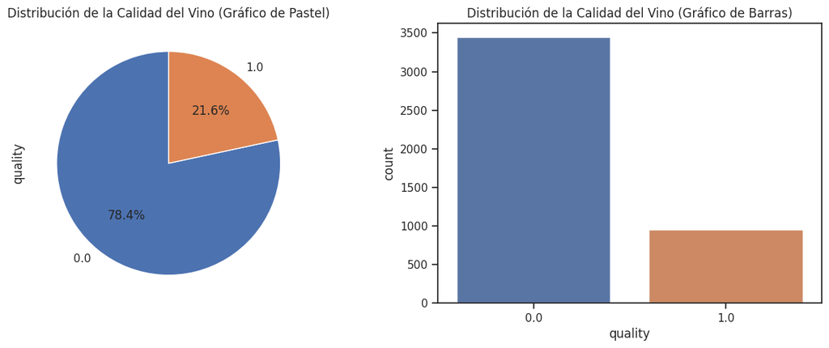

```python
print(wine_train['quality'].value_counts())

# Visualización de la calidad del vino en el conjunto de entrenamiento
fig, ax = plt.subplots(ncols=2, nrows=1, figsize=(15, 5))
ax = ax.flatten()

# Gráfico de pastel
wine_train['quality'].value_counts().plot(kind='pie', ax=ax[0], autopct='%1.1f%%', startangle=90)
ax[0].set_title('Distribución de la Calidad del Vino (Gráfico de Pastel)')

# Gráfico de barras
sns.countplot(x='quality', data=wine_train, ax=ax[1])
ax[1].set_title('Distribución de la Calidad del Vino (Gráfico de Barras)')

plt.show()
```

## Aplicando validación cruzada con K-Fold

> Se realiza la aplicación del método K-Fold para la estimación del desempeño en distintos modelos para la clasificación de vinos. Se realizará un proceso de 5 repeticiones repartiendo en 10 particiones cada repetición.

```python
# Número de interacciones k-fold
# Aquí se esta definiendo el número de particiones k-fold y el número de repeticiones que se realizarán.
# En este caso, se realizará una validación cruzada k-fold de 10 particiones y se repetirá 5 veces para aumentar la confiabilidad de las estimaciones.
k = 10
repeticiones = 5

# Se crean los arrays para almacenar las métricas de cada modelo en cada iteración k-fold
AD_Asertividad = np.zeros((repeticiones, k))
NB_Asertividad = np.zeros((repeticiones, k))
SVM_sigmoid_Asertividad = np.zeros((repeticiones, k))


# Validación cruzada con k-fold y repeticiones
# Este es el bucle principal donde se realiza la validación cruzada k-fold y las repeticiones.
# rep se utiliza para iterar a través de las repeticiones y se establece una semilla aleatoria diferente (random_state=rep)
# en cada repetición para asegurarse de que las particiones sean distintas.
for rep in range(repeticiones):
    kf = StratifiedKFold(n_splits=k, shuffle=True, random_state=rep)

    for i, (train_idx, test_idx) in enumerate(kf.split(wine_train, wine_train['quality'])):
        train_data = wine_train.iloc[train_idx]
        test_data = wine_train.iloc[test_idx]

        # Naive Bayes
        # Bloque de codigo para entrenar y evaluar el algoritmo Naive Bayes en cada partición K-fold
        nb = GaussianNB()
        nb.fit(train_data.drop(columns=['quality']), train_data['quality'])
        nb_predictions = nb.predict(test_data.drop(columns=['quality']))
        NB_Asertividad[rep, i] = accuracy_score(test_data['quality'], nb_predictions)

        # SVM Polinomial
        # Bloque de codigo para entrenar y evaluar el algoritmo SVM Polinomial en cada partición K-fold
        svm_sigmoid = SVC(kernel='sigmoid')
        svm_sigmoid.fit(train_data.drop(columns=['quality']), train_data['quality'])
        svm_sigmoid_predictions = svm_sigmoid.predict(test_data.drop(columns=['quality']))
        SVM_sigmoid_Asertividad[rep, i] = accuracy_score(test_data['quality'], svm_sigmoid_predictions)

        # Análisis Discriminante
        # Bloque de código para entrenar y evaluar el modelo Análisis discriminante en cada partición K-fold
        AD_clf = LinearDiscriminantAnalysis()
        AD_clf.fit(train_data.drop(columns=['quality']), train_data['quality'])
        AD_clf_predictions = AD_clf.predict(test_data.drop(columns=['quality']))
        AD_Asertividad[rep, i] = accuracy_score(test_data['quality'], AD_clf_predictions)


# Calculando el promedio de las métricas de cada modelo en las repeticiones

AD_Asertividad_mean = np.mean(AD_Asertividad, axis=0)
NB_Asertividad_mean = np.mean(NB_Asertividad, axis=0)
SVM_Sigmoid_Asertividad_mean = np.mean(SVM_sigmoid_Asertividad, axis=0)
```

A continuación, se realiza el siguiente código para crear un gráfico de barras que muestra las métricas de asertividad promedio para cada modelo, con barras de error para indicar la variabilidad en las repeticiones. El gráfico se muestra en una ventana emergente.

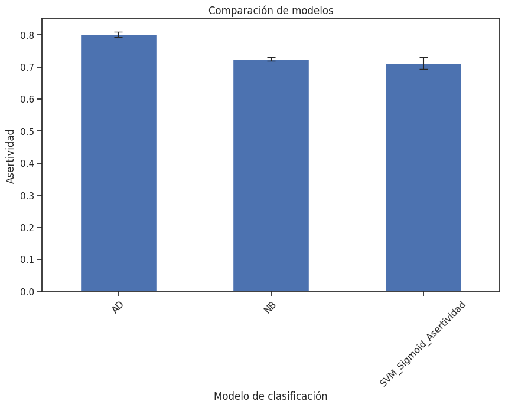

```python
# Creando el DataFrame que servira para graficar los resultados
data = {
    "AD": AD_Asertividad_mean,
    "NB": NB_Asertividad_mean,
    "SVM_Sigmoid_Asertividad": SVM_Sigmoid_Asertividad_mean
}

df_plot = pd.DataFrame(data)

# Graficando barras de error
plt.figure(figsize=(10, 6))
df_plot.mean().plot(kind='bar', yerr=df_plot.std(), capsize=5)
plt.xlabel("Modelo de clasificación")
plt.ylabel("Asertividad")
plt.title("Comparación de modelos")
plt.xticks(rotation=45)
plt.show()
```

## Análisis Discriminante

> En esa parte solamente, se realiza el entrenamiento por separado, del modelo que mejor porcentaje de asertividad tuvo dentro del método K-Fold, esto solamente para poder realizar la observación de cómo se comporta el porcentaje de asertividad fuera del método.

Primeramente importamos las librerías necesarias y entrenamos el modelo

```python
X_train = wine_train.iloc[:,0:11]
y_train = wine_train['quality']
clf = LinearDiscriminantAnalysis()

#Entrenamiento
clf.fit(X_train,y_train)
#Score general
clf.score(X_train,y_train)
```

```
0.8029064486830154
```

```python
bins = (3, 6, 9)
group_names = ['malo', 'bueno']
wine_test['quality'] = pd.cut(wine_test['quality'], bins = bins, labels = group_names)
wine_test
```

|  | fixed_acidity | volatile_acidity | citric_acid | residual_sugar | chlorides | free_sulfur_dioxide | total_sulfur_dioxide | density | pH | sulphates | alcohol | quality |
| --- | --- | --- | --- | --- | --- | --- | --- | --- | --- | --- | --- | --- |
| 1373 | 10.7 | 0.220 | 0.56 | 8.2 | 0.044 | 37.0 | 181.0 | 0.99800 | 2.87 | 0.68 | 9.5 | malo |
| 3962 | 7.2 | 0.580 | 0.27 | 5.8 | 0.032 | 40.0 | 118.0 | 0.99088 | 3.17 | 0.53 | 13.0 | bueno |
| 2028 | 8.9 | 0.210 | 0.34 | 7.1 | 0.037 | 33.0 | 150.0 | 0.99620 | 3.10 | 0.45 | 9.7 | malo |
| 2174 | 7.4 | 0.190 | 0.30 | 12.8 | 0.053 | 48.5 | 229.0 | 0.99860 | 3.14 | 0.49 | 9.1 | bueno |
| 4184 | 6.4 | 0.330 | 0.28 | 4.0 | 0.040 | 24.0 | 81.0 | 0.99030 | 3.26 | 0.64 | 12.6 | bueno |
| ... | ... | ... | ... | ... | ... | ... | ... | ... | ... | ... | ... | ... |
| 1079 | 6.3 | 0.340 | 0.29 | 6.2 | 0.046 | 29.0 | 227.0 | 0.99520 | 3.29 | 0.53 | 10.1 | malo |
| 1781 | 6.1 | 0.320 | 0.37 | 1.8 | 0.051 | 13.0 | 200.0 | 0.99450 | 3.49 | 0.44 | 10.5 | malo |
| 559 | 7.2 | 0.340 | 0.44 | 4.2 | 0.047 | 51.0 | 144.0 | 0.99100 | 3.01 | 0.76 | 12.3 | malo |
| 4621 | 7.5 | 0.305 | 0.38 | 1.4 | 0.047 | 30.0 | 95.0 | 0.99158 | 3.22 | 0.52 | 11.5 | bueno |
| 3308 | 6.4 | 0.350 | 0.28 | 12.6 | 0.039 | 19.0 | 124.0 | 0.99539 | 3.20 | 0.43 | 10.6 | malo |

487 rows × 12 columns

```python
wine_test['quality'] = wine_test['quality'].map({'malo' : 0, 'bueno' : 1})
wine_test

y_test = wine_test['quality']
X_test = wine_test.iloc[:,0:11]
```

```python
y_test = y_test.fillna(0)
```

```python
from sklearn.metrics import classification_report

y_pred = clf.predict(X_test)
print(classification_report(y_test,y_pred))
```

```
              precision    recall  f1-score   support

           0       0.83      0.94      0.88       382
           1       0.56      0.29      0.38       105

    accuracy                           0.80       487
   macro avg       0.69      0.61      0.63       487
weighted avg       0.77      0.80      0.77       487
```

```python
bins = (3, 6, 9)
group_names = ['malo', 'bueno']
wine_validate['quality'] = pd.cut(wine_validate['quality'], bins = bins, labels = group_names)
wine_validate.head()
wine_validate['quality'] = wine_validate['quality'].map({'malo' : 0, 'bueno' : 1})
wine_validate.head(10)
```

|  | fixed_acidity | volatile_acidity | citric_acid | residual_sugar | chlorides | free_sulfur_dioxide | total_sulfur_dioxide | density | pH | sulphates | alcohol | quality |
| --- | --- | --- | --- | --- | --- | --- | --- | --- | --- | --- | --- | --- |
| 817 | 6.6 | 0.56 | 0.22 | 8.9 | 0.034 | 27.0 | 133.0 | 0.99675 | 3.20 | 0.51 | 9.1 | 0 |
| 3898 | 8.5 | 0.23 | 0.34 | 1.3 | 0.035 | 54.0 | 110.0 | 0.99176 | 3.07 | 0.55 | 11.0 | 1 |
| 1826 | 6.5 | 0.32 | 0.12 | 11.5 | 0.033 | 35.0 | 165.0 | 0.99740 | 3.22 | 0.32 | 9.0 | 0 |
| 1274 | 8.4 | 0.35 | 0.56 | 13.8 | 0.048 | 55.0 | 190.0 | 0.99930 | 3.07 | 0.58 | 9.4 | 0 |
| 924 | 7.9 | 0.28 | 0.41 | 2.0 | 0.044 | 50.0 | 152.0 | 0.99340 | 3.45 | 0.49 | 10.7 | 1 |
| 4784 | 6.4 | 0.31 | 0.31 | 12.9 | 0.045 | 55.0 | 161.0 | 0.99546 | 3.02 | 0.59 | 10.2 | 0 |
| 2860 | 7.3 | 0.21 | 0.33 | 1.0 | 0.037 | 66.0 | 144.0 | 0.99230 | 3.11 | 0.52 | 10.2 | 0 |
| 4596 | 6.7 | 0.53 | 0.29 | 4.3 | 0.069 | 20.0 | 114.0 | 0.99014 | 3.22 | 0.59 | 13.4 | 0 |
| 1712 | 7.9 | 0.18 | 0.37 | 3.0 | 0.061 | 25.0 | 178.0 | 0.99500 | 3.22 | 0.51 | 10.0 | 0 |
| 1528 | 7.4 | 0.27 | 0.49 | 1.1 | 0.037 | 33.0 | 156.0 | 0.99200 | 3.15 | 0.54 | 11.1 | 0 |

```python
wine_validate.iloc[:, :-1]
```

|  | fixed_acidity | volatile_acidity | citric_acid | residual_sugar | chlorides | free_sulfur_dioxide | total_sulfur_dioxide | density | pH | sulphates | alcohol |
| --- | --- | --- | --- | --- | --- | --- | --- | --- | --- | --- | --- |
| 817 | 6.6 | 0.56 | 0.22 | 8.9 | 0.034 | 27.0 | 133.0 | 0.99675 | 3.20 | 0.51 | 9.1 |
| 3898 | 8.5 | 0.23 | 0.34 | 1.3 | 0.035 | 54.0 | 110.0 | 0.99176 | 3.07 | 0.55 | 11.0 |
| 1826 | 6.5 | 0.32 | 0.12 | 11.5 | 0.033 | 35.0 | 165.0 | 0.99740 | 3.22 | 0.32 | 9.0 |
| 1274 | 8.4 | 0.35 | 0.56 | 13.8 | 0.048 | 55.0 | 190.0 | 0.99930 | 3.07 | 0.58 | 9.4 |
| 924 | 7.9 | 0.28 | 0.41 | 2.0 | 0.044 | 50.0 | 152.0 | 0.99340 | 3.45 | 0.49 | 10.7 |
| ... | ... | ... | ... | ... | ... | ... | ... | ... | ... | ... | ... |
| 841 | 8.7 | 0.23 | 0.32 | 13.4 | 0.044 | 35.0 | 169.0 | 0.99975 | 3.12 | 0.47 | 8.8 |
| 3870 | 6.1 | 0.23 | 0.27 | 9.8 | 0.055 | 74.0 | 134.0 | 0.99534 | 3.16 | 0.40 | 10.2 |
| 4434 | 7.2 | 0.24 | 0.24 | 1.7 | 0.045 | 18.0 | 161.0 | 0.99196 | 3.25 | 0.53 | 11.2 |
| 4703 | 5.9 | 0.12 | 0.28 | 1.4 | 0.037 | 36.0 | 83.0 | 0.99074 | 3.33 | 0.42 | 10.9 |
| 2297 | 6.5 | 0.29 | 0.42 | 10.6 | 0.042 | 66.0 | 202.0 | 0.99674 | 3.24 | 0.53 | 9.5 |

494 rows × 11 columns

```python
wine_validate.head()
```

|  | fixed_acidity | volatile_acidity | citric_acid | residual_sugar | chlorides | free_sulfur_dioxide | total_sulfur_dioxide | density | pH | sulphates | alcohol | quality |
| --- | --- | --- | --- | --- | --- | --- | --- | --- | --- | --- | --- | --- |
| 817 | 6.6 | 0.56 | 0.22 | 8.9 | 0.034 | 27.0 | 133.0 | 0.99675 | 3.20 | 0.51 | 9.1 | 0 |
| 3898 | 8.5 | 0.23 | 0.34 | 1.3 | 0.035 | 54.0 | 110.0 | 0.99176 | 3.07 | 0.55 | 11.0 | 1 |
| 1826 | 6.5 | 0.32 | 0.12 | 11.5 | 0.033 | 35.0 | 165.0 | 0.99740 | 3.22 | 0.32 | 9.0 | 0 |
| 1274 | 8.4 | 0.35 | 0.56 | 13.8 | 0.048 | 55.0 | 190.0 | 0.99930 | 3.07 | 0.58 | 9.4 | 0 |
| 924 | 7.9 | 0.28 | 0.41 | 2.0 | 0.044 | 50.0 | 152.0 | 0.99340 | 3.45 | 0.49 | 10.7 | 1 |

# Validación o prueba

> Probar clasifiación con datos no utilizados en el proceso de aprendizaje (wine validate)

Modelos Naive Bayes, Análisis Discriminante y Suport Vector Machine.

```python
from sklearn.metrics import confusion_matrix
```

```python
#Validando SVM con Kernel Polinomial con el conjunto de datos wine_validate

wine_validate = wine_validate.fillna(axis=1, method="bfill").fillna(0)

prediccion_SVM = svm_sigmoid.predict(wine_validate.iloc[:, :-1])
tabla_SVM = pd.DataFrame(confusion_matrix(wine_validate['quality'], prediccion_SVM))
SVM_sigmoid = accuracy_score(wine_validate['quality'], prediccion_SVM)

tabla_SVM
```

|  | 0 | 1 |
| --- | --- | --- |
| 0 | 327 | 60 |
| 1 | 80 | 27 |

```python
SVM_sigmoid*100
```

```
71.65991902834008
```

```python
#Validando Naive Bayes con el conjunto de datos wine_validate

prediccion_NB = nb.predict(wine_validate.iloc[:, :-1])
tabla_NB = pd.DataFrame(confusion_matrix(wine_validate['quality'], prediccion_NB))
NB = accuracy_score(wine_validate['quality'], prediccion_NB)

tabla_NB
```

|  | 0 | 1 |
| --- | --- | --- |
| 0 | 286 | 101 |
| 1 | 38 | 69 |

```python
NB*100
```

```
71.86234817813765
```

```python
#Validando Análisis Discriminante con el conjunto de datos wine_validate

prediccion_AD = AD_clf.predict(wine_validate.iloc[:, :-1])
tabla_AD = pd.DataFrame(confusion_matrix(wine_validate['quality'], prediccion_AD))
AD = accuracy_score(wine_validate['quality'], prediccion_AD)

tabla_AD
```

|  | 0 | 1 |
| --- | --- | --- |
| 0 | 366 | 21 |
| 1 | 82 | 25 |

```python
AD*100
```

```
79.1497975708502
```